# Challenge 2: Maps

Solene Derville - solene.derville@oregonstate.edu

Feb 28, 2023

### Load R libraries

```r
library(sf)
library(ggpubr)
library(tidyverse)
library(patchwork)
library(raster)
library(ggsn)
library(png)
library(grid)
library(ggthemes)
```

### Load dataset

Extracted from GBIF: GBIF.org (09 May 2021) GBIF Occurrence Download https://doi.org/10.15468/dl.frb56w This file contains all GBIF occurrences of the Felidae family collected in Oregon (approximated by a box of longitude [-128.6, -119.3] and latitude [41.1, 46.2]), from 1900 to present (filtering out occurrences with uncertain coordinates)

```r
# import the csv in R into a dataframe. The .csv file needs to be in your working directory for this to work
# to change working directory, click on > Session > Set Working Directory > Choose Working Directory
dfel <- read.csv("dataset1_GBIF_observations.csv", sep = ";")

# this dataset has many columns, some of which are not necessary here so let's simplify the dataframe by selecting specific columns
dfel <- dfel %>%
  dplyr::select(gbifID, family, genus, species, individualCount, decimalLatitude, decimalLongitude, eventDate, month, year, institutionCode)
```

### Load environmental data

Extracted from GEBCO (elevation and bathymetry raster) and openstreetmap (coastline)

```r
# coastline shapefile
coast_sf <- st_read("coastline_openstreetmap_OR.shp")
# isobaths (every 50 m, up to 1000 m deep)
iso_sf <- st_read("isobaths_50mto1000m.shp")
```

```r
# elevation and bathymetry
r <- raster("dataset2_gebco_map.tif")
# convert to dataframe for use in ggplot2 (although there are ways to directly incorporate rasters in ggplot)
relief <- as.data.frame(r)
names(relief) <- "elev"
relief[c("lon", "lat")] <- coordinates(r)

# map of united states (source: wikipedia, modified in inkscape to highlight Oregon)
or <- readPNG("North_America_second_level_political_division_2.png", TRUE)
```

## Challenge objective: Create a map to look at the distribution of a marine family (Phocidae) and/or a terrestrial family (Felidae).

### Path to a quality map

1. You need to transform the data into a spatial format using the function `sf::st_as_sf` with `crs = 4326`. You can use `geom_sf` to plot all spatial objects
2. Beware of occurrences with missing speciesID or erroneous coordinates
3. Use `geom_tile` to plot elevation (or depth) based on the raster *r* converted in dataframe *relief*
4. Carefully select the extent and the graticules of your map with `coord_sf`
5. Add a scale and a north arrow with `ggsn::scalebar` and `ggsn::north`
6. Add an insert map to show where Oregon is located with `annotation_custom(rasterGrob())`.

### A few tips

- Relief contour lines may be created with `rasterToContour` and easily added to the plot once converted with `st_as_sf`
- Use color scales that match your terrestrial vs marine theme. Some ideas: https://www.canva.com/learn/100-color-combinations/ or https://github.com/EmilHvitfeldt/r-color-palettes

### Example

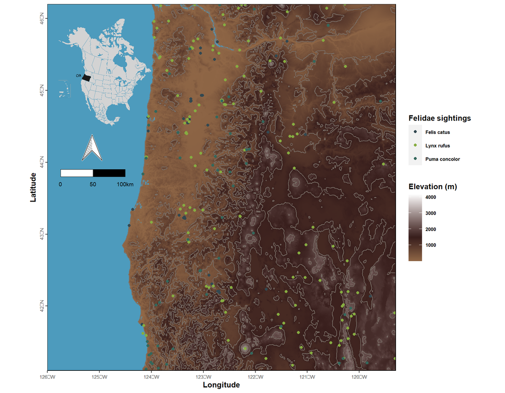

```r
# convert to spatial object in the lat/lon WGS84 coordinates system
dfel <- dfel %>%
  filter(!is.na(decimalLongitude) & !is.na(decimalLatitude)) %>%
  st_as_sf(coords = c("decimalLongitude", "decimalLatitude"), crs = 4326)

# get elevation lines every 500 m
relief_lines_land <- st_as_sf(rasterToContour(r, levels = seq(0, 5000, 500)))

# select only the part of the raster on land
relief_land <- relief[relief$elev > 0, ]

# set up my personal theme
mytheme <- theme(panel.border = element_rect(linewidth=0.5,color="black", fill="transparent"), #white background
        panel.background = element_rect(fill = 'white'),
        text=element_text(face="bold", size=8), #general size for all text.looks small here but ok once using ggsave with 600 dpi and default pointsize
        title = element_text(size=rel(1.2)),
        axis.text.y = element_text(angle = 90, hjust = 0.5)) # all titles will be a little larger than labels

# insert key map from png
north_america <- readPNG("North_America_second_level_political_division_2.png", TRUE)

g <- ggplot() +
  # plot the sea
  geom_tile(data = relief[relief$elev <= 0, ], aes(lon, lat), fill = "#4d9bbd") +
  # plot elevation in land
  geom_tile(data = relief[relief$elev > 0, ], aes(lon, lat, fill = elev)) +
  # add some relief lines with a light brown color
  geom_sf(data = relief_lines_land, col = "#7b7169", size = 0.2) +
  geom_sf(data = dfel, aes(col = species)) +
  coord_sf(xlim = c(-126, -119.3), expand = F) +
  # use a canva palette for observations
  scale_color_canva(name = "Felidae sightings", palette = "Playful greens and blues") +
  xlab("Longitude") + ylab ("Latitude") +
  # use a gradient palette for altitude
  scale_fill_gradient2(low = "#dfaa6c", mid = "#381e1c", high = "white", midpoint = 1500, name = "Elevation (m)") +
  # insert key map
  annotation_custom(
      rasterGrob(north_america),
      xmin = -126, xmax = -123.8,
      ymin = 44.5, ymax = 46) +
  # insert north arrow and scale bar. Positions are manually indicated with 'anchor'
  ggsn::north(dfel, symbol = 4, scale = 0.08, location = "bottomleft", anchor = c(x = -125.35, y = 44)) +
  ggsn::scalebar(dfel, dist = 50, dist_unit = "km", location = "bottomleft", transform = T, anchor = c(x = -125.75, y = 43.8), st.size = 2.5, border.size = 0.2) +
  mytheme
g
```

```r
ggsave(g, file = "Challenge2_map.png", width = 88*2, height = 120, dpi = 600, units = "mm")
```